# Práctica

## Objetivos

- Investigar diferentes algoritmos de clasificación en aprendizaje automático.
- Aplicar y evaluar al menos dos técnicas de clasificación en un conjunto de datos real.

## Desarrollo

### Investigación Teórica

[figure not shown]

#### Máquina de Soporte Vectorial

Las máquinas vectoriales de soporte (SVM) son un conjunto de métodos de aprendizaje supervisado utilizados para la clasificación, la regresión y la detección de valores atípicos.

Las ventajas de las máquinas vectores de soporte son:

- Efectivo en espacios de alta dimensión.
- Sigue siendo efectivo en los casos en que el número de dimensiones es mayor que el número de muestras.
- Utiliza un subconjunto de puntos de entrenamiento en la función de decisión (llamados vectores de soporte), por lo que también es eficiente en la memoria.
- Versátil: se pueden especificar diferentes funciones del núcleo para la función de decisión. Se proporcionan núcleos comunes, pero también es posible especificar núcleos personalizados.

Las desventajas de las máquinas vectores de soporte incluyen:

- Si el número de características es mucho mayor que el número de muestras, evite el ajuste excesivo al elegir las funciones del núcleo y el plazo de regularización es crucial.
- Los SVM no proporcionan directamente estimaciones de probabilidad, estas se calculan utilizando una costosa validación cruzada de cinco veces.

**Clasificación**

SVC,NuSVC y LinearSVC son clases capaces de realizar una clasificación binaria y multiclase en un conjunto de datos.

SVC y NuSVC son métodos, pero aceptan conjuntos de parámetros ligeramente diferentes y tienen diferentes formulaciones matemáticas. Por otro lado, LinearSVC es otra implementación (más rápida) de Clasificación de vectores de soporte para el caso de un núcleo lineal. También carece de algunos de los atributos de SVC y NuSVC, como support_.LinearSVC usa squared_hinge loss y debido a su implementación en liblinear también regulariza la intercepción, si se considera. Sin embargo, este efecto se puede reducir ajustando cuidadosamente su parámetro intercept_scaling, lo que permite que el término de intercepción tenga un comportamiento de regularización diferente en comparación con las otras características. Por lo tanto, los resultados de la clasificación y la puntuación pueden diferir de los de los otros dos clasificadores.

[figure not shown]

Decision_function para una muestra $x$ dada se convierte en:

$$\sum_{i \in SV}^{} y_i \alpha_i K(X_I,X)+B $$

y la clase predicha corresponde a su signo. Solo necesitamos sumar los vectores de soporte (es decir, las muestras que se encuentran dentro del margen) porque los coeficientes duales $\alpha_i$ son cero para las otras muestras.

#### Stochastic Gradient Descent (SGD)

Stochastic Gradient Descent (SGD) es un enfoque simple pero muy eficiente para ajustar los clasificadores lineales y los retornos a las funciones de pérdida subconvexa, como las máquinas vectoriales de soporte (lineal) y la regresión logística. Estrictamente hablando, el SGD es simplemente una técnica de optimización y no se corresponde con una familia específica de modelos de aprendizaje automático. Es solo una forma de entrenar a un modelo.

Las ventajas de la decreciente de gradiente estocástico son:

- Eficiencia.
- Facilidad de implementación (muchas oportunidades para ajustar el código).

Las desventajas del descenso de gradiente estocástico incluyen:

- SGD requiere una serie de hiperparámetros, como el parámetro de regularización y el número de iteraciones.
- SGD es sensible al escalado de características.

**Clasificación**

La clase SGDClassifier implementa una rutina de aprendizaje de descenso de gradiente estocástico simple que admite diferentes funciones de pérdida y sanciones para la clasificación. A continuación se muestra el límite de decisión de unSGDClassifierentrenado con la pérdida de la bisagra, equivalente a un SVM lineal.

[figure not shown]

La clase SGDClassifier implementa una rutina de aprendizaje SGD de primer orden. El algoritmo itera sobre los ejemplos de entrenamiento y para cada ejemplo actualiza los parámetros del modelo de acuerdo con la regla de actualización dada por:

$$ w \leftarrow w - \eta [\alpha \frac{\partial R(w)}{\partial w} + \frac{\partial L (w^T x_i + b,y_i)}{\partial w}] $$

#### KNN

El principio detrás de los métodos de vecino más cercano es encontrar un número predefinido de muestras de entrenamiento más cercanas en distancia al nuevo punto y predecir la etiqueta a partir de ellas. El número de muestras puede ser una constante definida por el usuario (aprendizaje del vecino más cercano más cercano), o variar en función de la densidad local de puntos (aprendizaje del vecino basado en el radio). La distancia puede, en general, ser cualquier medida métrica: la distancia euclidiana estándar es la opción más común. Los métodos basados en vecinos se conocen como métodos de aprendizaje automático no generalizadores, ya que simplemente "recuerdan" todos sus datos de entrenamiento (posiblemente transformados en una estructura de indexación rápida como un árbol de bolas o un árbol KD).

Ventajas de K-NN:

- Simplicidad y Fácil Implementación: K-NN es fácil de entender y implementar, lo que lo hace accesible para aquellos que están empezando en el aprendizaje automático.
- No Paramétrico: Es un algoritmo no paramétrico, lo que significa que no hace suposiciones sobre la forma de los datos, permitiendo adaptarse a patrones complejos.
- Adaptabilidad a Cambios en los Datos: K-NN puede adaptarse a nuevos datos sin necesidad de reentrenamiento completo. Es especialmente útil cuando el conjunto de datos está en constante cambio.
- Robusto ante Datos Ruidosos: K-NN puede manejar datos ruidosos y valores atípicos, ya que se basa en la mayoría de los votos de los vecinos cercanos.
- No Linealidad: Puede manejar decisiones de clasificación no lineales, ya que no hace suposiciones sobre la forma de los límites de decisión.

Desventajas de K-NN:

- Sensibilidad a la Dimensionalidad: K-NN puede volverse menos efectivo a medida que aumenta la dimensionalidad de los datos debido al problema de la maldición de la dimensionalidad.
- Costo Computacional: El tiempo de búsqueda de vecinos puede ser costoso computacionalmente, especialmente en conjuntos de datos grandes, ya que se requiere calcular las distancias entre la instancia de prueba y todas las instancias de entrenamiento.
- Dependencia del Valor de k: La elección del valor de k puede afectar significativamente los resultados. Un valor de k demasiado pequeño puede hacer que el modelo sea sensible al ruido, mientras que un valor demasiado grande puede suavizar demasiado las fronteras de decisión.
- Dependencia de la Escala: K-NN es sensible a la escala de las características, por lo que es importante normalizar o estandarizar los datos antes de aplicar el algoritmo.
- Problemas con Datos Espaciados de Manera Desigual: Si los datos están espaciados de manera desigual, K-NN puede ser influenciado por la densidad local de puntos, lo que puede afectar la calidad de las predicciones.
- Problemas con Atributos Irrelevantes: Atributos irrelevantes pueden afectar negativamente el rendimiento de K-NN, ya que contribuyen al cálculo de distancias sin agregar información significativa.

**Clasificación**

La clasificación basada en vecinos es un tipo de aprendizaje basado en instancias o aprendizaje no generalizado: no intenta construir un modelo interno general, sino que simplemente almacena instancias de los datos de entrenamiento. La clasificación se calcula a partir de un voto de mayoría simple de los vecinos más cercanos de cada punto: a un punto de consulta se le asigna la clase de datos que tiene la mayor cantidad de representantes dentro de los vecinos más cercanos del punto.

scikit-learn implementa dos clasificadores diferentes de vecinos más cercanos:KNeighborsClassifierimplementa el aprendizaje basado en el k vecinos más cercanos de cada punto de consulta, dondees k un valor entero especificado por el usuario.RadiusNeighborsClassifierimplementa el aprendizaje basado en el número de vecinos dentro de un radio fijo r de cada punto de entrenamiento, donde r es un valor de coma flotante especificado por el usuario.

los k-clasificación de vecinos enKNeighborsClassifieres la técnica más utilizada. La elección óptima del valor k es altamente dependiente de los datos: en general, un mayor k suprime los efectos del ruido, pero hace que los límites de clasificación sean menos distintos.

En los casos en que los datos no se muestrean de manera uniforme, la clasificación de vecinos basada en el radio enRadiusNeighborsClassifierpuede ser una mejor opción. El usuario especifica un radio fijo r, de modo que los puntos en los barrios más escasos utilizan menos vecinos más cercanos para la clasificación. Para los espacios de parámetros de alta dimensión, este método se vuelve menos efectivo debido a la llamada "maldita de dimensionalidad".

[figure not shown]

#### Naive Bayes

Los métodos ingenuos de Bayes son un conjunto de algoritmos de aprendizaje supervisados basados en la aplicación del teorema de Bayes con la suposición "naive" de independencia condicional entre cada par de características dado el valor de la variable de clase. El teorema de Bayes establece la siguiente relación, dada la variable de clase $y$ y vector de características dependientes $x_1$ a través de $x_n$:

$$ P(y | x_1, ..., x_n)= \frac{P(y)P(x_1, ..., x_n|y)}{P(x_1, ..., x_n)} $$

Los diferentes clasificadores ingenuos de Bayes difieren principalmente en las suposiciones que hacen con respecto a la distribución de $P(x_i|y)$.

A pesar de sus suposiciones aparentemente demasiado simplificadas, los ingenuos clasificadores de Bayes han funcionado bastante bien en muchas situaciones del mundo real, como la clasificación de documentos y el filtrado de spam. Requieren una pequeña cantidad de datos de entrenamiento para estimar los parámetros necesarios.

GaussianNBimplementa el algoritmo Gaussian Naive Bayes para la clasificación. Se supone que la probabilidad de las características es gaussiana:

$$P(x_i|y)= \frac{1}{\sqrt{2 \pi \sigma_{y}^{2}}} exp(- \frac{(x_i- \mu_y)^2}{2 \sigma_{y}^{2}})$$

Ventajas de Naive Bayes:

- Simplicidad y Fácil Implementación: Naive Bayes es un algoritmo simple y fácil de implementar, lo que lo hace rápido y accesible para problemas de clasificación.
- Eficiencia Computacional: En general, el tiempo de entrenamiento y predicción de Naive Bayes es rápido, incluso para conjuntos de datos grandes.
- Manejo de Atributos Categóricos: Es efectivo en la clasificación de datos con atributos categóricos y numéricos.
- Manejo de Conjuntos de Datos de Alta Dimensión: Naive Bayes puede funcionar bien en conjuntos de datos de alta dimensión y es menos propenso a la maldición de la dimensionalidad.
- Requiere Poca Data para Entrenar: A menudo, Naive Bayes funciona bien incluso con conjuntos de datos relativamente pequeños, lo que es beneficioso cuando la cantidad de datos de entrenamiento es limitada.

Desventajas de Naive Bayes:

- Suposición de Independencia: La principal limitación de Naive Bayes es la suposición de independencia condicional entre las características, lo que puede no ser realista en algunos casos.
- No Modela Relaciones Complejas: Naive Bayes tiende a no funcionar tan bien en problemas donde las relaciones entre las características son complejas o no lineales.
- Sensible a Atributos Irrelevantes: Aunque es robusto frente a atributos irrelevantes, aún puede ser afectado por características que violan la suposición de independencia.
- Estimaciones de Probabilidad Pueden Ser Sesgadas: En conjuntos de datos pequeños, las estimaciones de probabilidad pueden ser sesgadas, lo que puede afectar la calidad de las predicciones.
- No Maneja Bien el Desbalance de Clases: Puede tener problemas al tratar con conjuntos de datos donde las clases están desbalanceadas, ya que tiende a sesgarse hacia la clase dominante.
- Mal Desempeño en Problemas de Regresión: Aunque Naive Bayes es comúnmente utilizado para clasificación, no es adecuado para problemas de regresión.
- Dependiente de la Calidad de los Datos: La calidad de las predicciones depende en gran medida de la calidad de los datos de entrenamiento, y puede ser afectada negativamente por datos ruidosos.

#### Árboles de Clasificación

Los árboles de decisión (DT) son un método de aprendizaje supervisado no paramétrico utilizado para la clasificación y la regresión. El objetivo es crear un modelo que prediga el valor de una variable objetivo aprendiendo reglas de decisión simples inferidas de las características de los datos. Un árbol puede verse como una aproximación constante a trozos.

Por ejemplo, en el siguiente ejemplo, los árboles de decisión aprenden de los datos para aproximarse a una curva sinusoidal con un conjunto de reglas de decisión if-then-else. Cuanto más profundo sea el árbol, más complejas son las reglas de decisión y más ajustado es el modelo.

[figure not shown]

Algunas ventajas de los árboles de decisión son:

- Fácil de entender e interpretar. Los árboles se pueden visualizar.
- Requiere poca preparación de datos. Otras técnicas a menudo requieren la normalización de los datos, es necesario crear variables ficticias y eliminar los valores en blanco. Algunas combinaciones de árboles y algoritmos admiten valores que faltan.
- El costo de usar el árbol (es decir, predecir datos) es logarítmico en el número de puntos de datos utilizados para entrenar el árbol.
- Capaz de manejar datos numéricos y categóricos. Sin embargo, la implementación de scikit-learn no admite variables categóricas por ahora. Otras técnicas suelen estar especializadas en el análisis de conjuntos de datos que tienen un solo tipo de variable. Consulte los algoritmos para obtener más información.
- Capaz de manejar problemas de salida múltiple.
- Utiliza un modelo de caja blanca. Si una situación dada es observable en un modelo, la explicación de la condición se explica fácilmente con la lógica booleana. Por el contrario, en un modelo de caja negra (por ejemplo, en una red neuronal artificial), los resultados pueden ser más difíciles de interpretar.
- Es posible validar un modelo utilizando pruebas estadísticas. Eso hace posible tener en cuenta la fiabilidad del modelo.
- Funciona bien incluso si sus suposiciones son algo violadas por el verdadero modelo a partir del cual se generaron los datos.

Las desventajas de los árboles de decisión incluyen:

- Los estudiantes del árbol de decisiones pueden crear árboles demasiado complejos que no generalizan bien los datos. Esto se llama sobreajuste. Para evitar este problema son necesarios mecanismos como la poda, el establecimiento del número mínimo de muestras requeridas en un nodo de la hoja o el establecimiento de la profundidad máxima del árbol.
- Los árboles de decisión pueden ser inestables porque pequeñas variaciones en los datos pueden dar lugar a la generación de un árbol completamente diferente. Este problema se mitiga mediante el uso de árboles de decisión dentro de un conjunto.
- Las predicciones de los árboles de decisión no son ni suaves ni continuas, sino aproximaciones constantes a trozos como se ve en la figura anterior. Por lo tanto, no son buenos en la extrapolación.
- Se sabe que el problema de aprender un árbol de decisiones óptimo es NP-completo bajo varios aspectos de la optimización e incluso para conceptos simples. En consecuencia, los algoritmos prácticos de aprendizaje del árbol de decisiones se basan en algoritmos heurísticos como el algoritmo codicioso, donde se toman decisiones localmente óptimas en cada nodo. Tales algoritmos no pueden garantizar el retorno del árbol de decisiones óptimo a nivel mundial. Esto se puede mitigar entrenando múltiples árboles en un alumno de conjunto, donde las características y las muestras se muestrean al azar con reemplazo.
- Hay conceptos que son difíciles de aprender porque los árboles de decisión no los expresan fácilmente, como XOR, paridad o problemas de multiplexores.
- Los estudiantes del árbol de decisiones crean árboles sesgados si dominan algunas clases. Por lo tanto, se recomienda equilibrar el conjunto de datos antes de encajar con el árbol de decisiones.

**Clasificación**

Al igual que con otros clasificadores,DecisionTreeClassifier toma como entrada two arrays: an array X, sparse or dense, of shape (n_samples, n_features) holding the training samples, and an array Y of integer values, shape (n_samples,), holding the class labels for the training sample.

[figure not shown]

#### Red Neuronal Artificial

El Perceptrón multicapa (MLP) es un algoritmo de aprendizaje supervisado que aprende una función $f():R^m \longrightarrow R°$ entrenando en un conjunto de datos, donde $m$ es el número de dimensiones para la entrada yes el número de dimensiones para la salida. Dado un conjunto de características $X=x_1,x_2, ..., x_{...}$ y un objetivo $y$, puede aprender un aproximador de función no lineal para la clasificación o la regresión. Es diferente de la regresión logística, en el sentido de que entre la capa de entrada y la de salida, puede haber una o más capas no lineales, llamadas capas ocultas. La figura 1 muestra una capa oculta MLP con salida escalar.

[figure not shown]

La capa más a la izquierda, conocida como capa de entrada, consiste en un conjunto de neuronas $[x_i|x_1,x_2,...,x_m]$ representando las características de entrada. Cada neurona en la capa oculta transforma los valores de la capa anterior con una suma lineal ponderada $w_1 x_1+w_2 x_2+...+w_m x_m$, seguido de una función de activación no lineal $g():R \longrightarrow R$ como la función de bronceado hiperbólico. La capa de salida recibe los valores de la última capa oculta y los transforma en valores de salida.

Las ventajas de Multi-layer Perceptron son:

- Capacidad para aprender modelos no lineales.
- Capacidad para aprender modelos en tiempo real (aprendizaje en línea) usando partial_fit.

Las desventajas del Perceptrón multicapa (MLP) incluyen:

- El MLP con capas ocultas tiene una función de pérdida no convexa donde existe más de un mínimo local. Por lo tanto, diferentes inicializaciones de peso aleatorio pueden conducir a una precisión de validación diferente.
- MLP requiere ajustar una serie de hiperparámetros, como el número de neuronas ocultas, capas e iteraciones.
- MLP es sensible al escalado de características.

**Clasifiación**

Class MLPClassifier implements a multi-layer perceptron (MLP) algorithm that trains using Backpropagation.

MLP entrena en dos matrices: matriz X de tamaño (n_samples, n_features), que contiene las muestras de entrenamiento representadas como vectores de características de punto flotante; y matriz y de tamaño (n_samples,), que contiene los valores objetivo (etiquetas de clase) para las muestras de entrenamiento

### Preparación de Datos

#### Reursos necesarios

- Acceso al dataset de Kaggle.
- Herramientas de análisis. Python con bibliotecas (pandas, numpy, scikit-learn, matplotlib).

```python
import pandas as pd
import numpy as np
import matplotlib.pyplot as plt
import seaborn as sns
from ydata_profiling import ProfileReport
```

```python
df = pd.read_csv('healthcare_dataset.csv')
```

```python
df
```

|  | Name | Age | Gender | Blood Type | Medical Condition | Date of Admission | Doctor | Hospital | Insurance Provider | Billing Amount | Room Number | Admission Type | Discharge Date | Medication | Test Results |
| --- | --- | --- | --- | --- | --- | --- | --- | --- | --- | --- | --- | --- | --- | --- | --- |
| 0 | Tiffany Ramirez | 81 | Female | O- | Diabetes | 2022-11-17 | Patrick Parker | Wallace-Hamilton | Medicare | 37490.983364 | 146 | Elective | 2022-12-01 | Aspirin | Inconclusive |
| 1 | Ruben Burns | 35 | Male | O+ | Asthma | 2023-06-01 | Diane Jackson | Burke, Griffin and Cooper | UnitedHealthcare | 47304.064845 | 404 | Emergency | 2023-06-15 | Lipitor | Normal |
| 2 | Chad Byrd | 61 | Male | B- | Obesity | 2019-01-09 | Paul Baker | Walton LLC | Medicare | 36874.896997 | 292 | Emergency | 2019-02-08 | Lipitor | Normal |
| 3 | Antonio Frederick | 49 | Male | B- | Asthma | 2020-05-02 | Brian Chandler | Garcia Ltd | Medicare | 23303.322092 | 480 | Urgent | 2020-05-03 | Penicillin | Abnormal |
| 4 | Mrs. Brandy Flowers | 51 | Male | O- | Arthritis | 2021-07-09 | Dustin Griffin | Jones, Brown and Murray | UnitedHealthcare | 18086.344184 | 477 | Urgent | 2021-08-02 | Paracetamol | Normal |
| ... | ... | ... | ... | ... | ... | ... | ... | ... | ... | ... | ... | ... | ... | ... | ... |
| 9995 | James Hood | 83 | Male | A+ | Obesity | 2022-07-29 | Samuel Moody | Wood, Martin and Simmons | UnitedHealthcare | 39606.840083 | 110 | Elective | 2022-08-02 | Ibuprofen | Abnormal |
| 9996 | Stephanie Evans | 47 | Female | AB+ | Arthritis | 2022-01-06 | Christopher Yates | Nash-Krueger | Blue Cross | 5995.717488 | 244 | Emergency | 2022-01-29 | Ibuprofen | Normal |
| 9997 | Christopher Martinez | 54 | Male | B- | Arthritis | 2022-07-01 | Robert Nicholson | Larson and Sons | Blue Cross | 49559.202905 | 312 | Elective | 2022-07-15 | Ibuprofen | Normal |
| 9998 | Amanda Duke | 84 | Male | A+ | Arthritis | 2020-02-06 | Jamie Lewis | Wilson-Lyons | UnitedHealthcare | 25236.344761 | 420 | Urgent | 2020-02-26 | Penicillin | Normal |
| 9999 | Eric King | 20 | Male | B- | Arthritis | 2023-03-22 | Tasha Avila | Torres, Young and Stewart | Aetna | 37223.965865 | 290 | Emergency | 2023-04-15 | Penicillin | Abnormal |

10000 rows × 15 columns

Ejecutar esta linea para la visualización de los diagramas del DataFrame.

```python
ProfileReport(df)
```

[interactive chart not shown]

```python
df.info()
```

```
<class 'pandas.core.frame.DataFrame'>
RangeIndex: 10000 entries, 0 to 9999
Data columns (total 15 columns):
 #   Column              Non-Null Count  Dtype
---  ------              --------------  -----
 0   Name                10000 non-null  object
 1   Age                 10000 non-null  int64
 2   Gender              10000 non-null  object
 3   Blood Type          10000 non-null  object
 4   Medical Condition   10000 non-null  object
 5   Date of Admission   10000 non-null  object
 6   Doctor              10000 non-null  object
 7   Hospital            10000 non-null  object
 8   Insurance Provider  10000 non-null  object
 9   Billing Amount      10000 non-null  float64
 10  Room Number         10000 non-null  int64
 11  Admission Type      10000 non-null  object
 12  Discharge Date      10000 non-null  object
 13  Medication          10000 non-null  object
 14  Test Results        10000 non-null  object
dtypes: float64(1), int64(2), object(12)
memory usage: 1.1+ MB
```

```python
df.isna().sum()
```

```
Name                  0
Age                   0
Gender                0
Blood Type            0
Medical Condition     0
Date of Admission     0
Doctor                0
Hospital              0
Insurance Provider    0
Billing Amount        0
Room Number           0
Admission Type        0
Discharge Date        0
Medication            0
Test Results          0
dtype: int64
```

**Gender**

```python
frequency_map = df['Gender'].value_counts().to_dict()
print (frequency_map)
```

```
{'Female': 5075, 'Male': 4925}
```

**Blood Type**

```python
frequency_map = df['Blood Type'].value_counts().to_dict()
print (frequency_map)
```

```
{'AB-': 1275, 'AB+': 1258, 'B-': 1252, 'O+': 1248, 'O-': 1244, 'B+': 1244, 'A+': 1241, 'A-': 1238}
```

**Medical Condition**

```python
frequency_map = df['Medical Condition'].value_counts().to_dict()
print (frequency_map)
```

```
{'Asthma': 1708, 'Cancer': 1703, 'Hypertension': 1688, 'Arthritis': 1650, 'Obesity': 1628, 'Diabetes': 1623}
```

**Doctor**

```python
frequency_map = df['Doctor'].value_counts().to_dict()
print (frequency_map)
```

```
{'Michael Johnson': 7, 'Robert Brown': 5, 'Michelle Anderson': 5, 'Matthew Smith': 5, 'Jennifer Smith': 5, 'James Williams': 5, 'James Perez': 5, 'Michael Smith': 5, 'David Johnson': 4, 'Christopher Davis': 4, 'Robert Miller': 4, 'William Rodriguez': 4, 'Christopher Jones': 4, 'Michael Brown': 4, 'A…
```

**Hospital**

```python
frequency_map = df['Hospital'].value_counts().to_dict()
print (frequency_map)
```

```
{'Smith PLC': 19, 'Smith and Sons': 17, 'Smith Ltd': 14, 'Smith Inc': 14, 'Johnson PLC': 13, 'Williams LLC': 12, 'Smith Group': 12, 'Williams Inc': 12, 'Johnson Group': 11, 'Johnson Ltd': 11, 'Thomas Group': 11, 'Brown LLC': 10, 'Jones Inc': 9, 'Davis and Sons': 9, 'Williams Group': 9, 'Jones LLC': …
```

**Insurance Provider**

```python
frequency_map = df['Insurance Provider'].value_counts().to_dict()
print (frequency_map)
```

```
{'Cigna': 2040, 'Blue Cross': 2032, 'Aetna': 2025, 'UnitedHealthcare': 1978, 'Medicare': 1925}
```

**Admission Type**

```python
frequency_map = df['Admission Type'].value_counts().to_dict()
print (frequency_map)
```

```
{'Urgent': 3391, 'Emergency': 3367, 'Elective': 3242}
```

**Medication**

```python
frequency_map = df['Medication'].value_counts().to_dict()
print (frequency_map)
```

```
{'Penicillin': 2079, 'Lipitor': 2015, 'Ibuprofen': 1976, 'Aspirin': 1968, 'Paracetamol': 1962}
```

**Test Results**

```python
frequency_map = df['Test Results'].value_counts().to_dict()
print (frequency_map)
```

```
{'Abnormal': 3456, 'Inconclusive': 3277, 'Normal': 3267}
```

```python
df
```

|  | Name | Age | Gender | Blood Type | Medical Condition | Date of Admission | Doctor | Hospital | Insurance Provider | Billing Amount | Room Number | Admission Type | Discharge Date | Medication | Test Results |
| --- | --- | --- | --- | --- | --- | --- | --- | --- | --- | --- | --- | --- | --- | --- | --- |
| 0 | Tiffany Ramirez | 81 | Female | O- | Diabetes | 2022-11-17 | Patrick Parker | Wallace-Hamilton | Medicare | 37490.983364 | 146 | Elective | 2022-12-01 | Aspirin | Inconclusive |
| 1 | Ruben Burns | 35 | Male | O+ | Asthma | 2023-06-01 | Diane Jackson | Burke, Griffin and Cooper | UnitedHealthcare | 47304.064845 | 404 | Emergency | 2023-06-15 | Lipitor | Normal |
| 2 | Chad Byrd | 61 | Male | B- | Obesity | 2019-01-09 | Paul Baker | Walton LLC | Medicare | 36874.896997 | 292 | Emergency | 2019-02-08 | Lipitor | Normal |
| 3 | Antonio Frederick | 49 | Male | B- | Asthma | 2020-05-02 | Brian Chandler | Garcia Ltd | Medicare | 23303.322092 | 480 | Urgent | 2020-05-03 | Penicillin | Abnormal |
| 4 | Mrs. Brandy Flowers | 51 | Male | O- | Arthritis | 2021-07-09 | Dustin Griffin | Jones, Brown and Murray | UnitedHealthcare | 18086.344184 | 477 | Urgent | 2021-08-02 | Paracetamol | Normal |
| ... | ... | ... | ... | ... | ... | ... | ... | ... | ... | ... | ... | ... | ... | ... | ... |
| 9995 | James Hood | 83 | Male | A+ | Obesity | 2022-07-29 | Samuel Moody | Wood, Martin and Simmons | UnitedHealthcare | 39606.840083 | 110 | Elective | 2022-08-02 | Ibuprofen | Abnormal |
| 9996 | Stephanie Evans | 47 | Female | AB+ | Arthritis | 2022-01-06 | Christopher Yates | Nash-Krueger | Blue Cross | 5995.717488 | 244 | Emergency | 2022-01-29 | Ibuprofen | Normal |
| 9997 | Christopher Martinez | 54 | Male | B- | Arthritis | 2022-07-01 | Robert Nicholson | Larson and Sons | Blue Cross | 49559.202905 | 312 | Elective | 2022-07-15 | Ibuprofen | Normal |
| 9998 | Amanda Duke | 84 | Male | A+ | Arthritis | 2020-02-06 | Jamie Lewis | Wilson-Lyons | UnitedHealthcare | 25236.344761 | 420 | Urgent | 2020-02-26 | Penicillin | Normal |
| 9999 | Eric King | 20 | Male | B- | Arthritis | 2023-03-22 | Tasha Avila | Torres, Young and Stewart | Aetna | 37223.965865 | 290 | Emergency | 2023-04-15 | Penicillin | Abnormal |

10000 rows × 15 columns

```python
df.drop('Date of Admission', axis=1, inplace=True)
```

```python
df.drop('Doctor', axis=1, inplace=True)
```

```python
df.drop('Hospital', axis=1, inplace=True)
```

```python
df.drop('Discharge Date', axis=1, inplace=True)
```

```python
df.drop('Name', axis=1, inplace=True)
```

```python
df
```

|  | Age | Gender | Blood Type | Medical Condition | Insurance Provider | Billing Amount | Room Number | Admission Type | Medication | Test Results |
| --- | --- | --- | --- | --- | --- | --- | --- | --- | --- | --- |
| 0 | 81 | Female | O- | Diabetes | Medicare | 37490.983364 | 146 | Elective | Aspirin | Inconclusive |
| 1 | 35 | Male | O+ | Asthma | UnitedHealthcare | 47304.064845 | 404 | Emergency | Lipitor | Normal |
| 2 | 61 | Male | B- | Obesity | Medicare | 36874.896997 | 292 | Emergency | Lipitor | Normal |
| 3 | 49 | Male | B- | Asthma | Medicare | 23303.322092 | 480 | Urgent | Penicillin | Abnormal |
| 4 | 51 | Male | O- | Arthritis | UnitedHealthcare | 18086.344184 | 477 | Urgent | Paracetamol | Normal |
| ... | ... | ... | ... | ... | ... | ... | ... | ... | ... | ... |
| 9995 | 83 | Male | A+ | Obesity | UnitedHealthcare | 39606.840083 | 110 | Elective | Ibuprofen | Abnormal |
| 9996 | 47 | Female | AB+ | Arthritis | Blue Cross | 5995.717488 | 244 | Emergency | Ibuprofen | Normal |
| 9997 | 54 | Male | B- | Arthritis | Blue Cross | 49559.202905 | 312 | Elective | Ibuprofen | Normal |
| 9998 | 84 | Male | A+ | Arthritis | UnitedHealthcare | 25236.344761 | 420 | Urgent | Penicillin | Normal |
| 9999 | 20 | Male | B- | Arthritis | Aetna | 37223.965865 | 290 | Emergency | Penicillin | Abnormal |

10000 rows × 10 columns

0 Mujeres, 1 Hombres

```python
mapeo_categorias = {'Female': 0, 'Male': 1}

df['Gender'] = df['Gender'].replace(mapeo_categorias)
```

```python
df
```

|  | Age | Gender | Blood Type | Medical Condition | Insurance Provider | Billing Amount | Room Number | Admission Type | Medication | Test Results |
| --- | --- | --- | --- | --- | --- | --- | --- | --- | --- | --- |
| 0 | 81 | 0 | O- | Diabetes | Medicare | 37490.983364 | 146 | Elective | Aspirin | Inconclusive |
| 1 | 35 | 1 | O+ | Asthma | UnitedHealthcare | 47304.064845 | 404 | Emergency | Lipitor | Normal |
| 2 | 61 | 1 | B- | Obesity | Medicare | 36874.896997 | 292 | Emergency | Lipitor | Normal |
| 3 | 49 | 1 | B- | Asthma | Medicare | 23303.322092 | 480 | Urgent | Penicillin | Abnormal |
| 4 | 51 | 1 | O- | Arthritis | UnitedHealthcare | 18086.344184 | 477 | Urgent | Paracetamol | Normal |
| ... | ... | ... | ... | ... | ... | ... | ... | ... | ... | ... |
| 9995 | 83 | 1 | A+ | Obesity | UnitedHealthcare | 39606.840083 | 110 | Elective | Ibuprofen | Abnormal |
| 9996 | 47 | 0 | AB+ | Arthritis | Blue Cross | 5995.717488 | 244 | Emergency | Ibuprofen | Normal |
| 9997 | 54 | 1 | B- | Arthritis | Blue Cross | 49559.202905 | 312 | Elective | Ibuprofen | Normal |
| 9998 | 84 | 1 | A+ | Arthritis | UnitedHealthcare | 25236.344761 | 420 | Urgent | Penicillin | Normal |
| 9999 | 20 | 1 | B- | Arthritis | Aetna | 37223.965865 | 290 | Emergency | Penicillin | Abnormal |

10000 rows × 10 columns

'AB-': 1, 'AB+': 2, 'B-': 3, 'O+': 4, 'O-': 5, 'B+': 6, 'A+': 7, 'A-': 8

```python
mapeo_categorias = {'AB-': 1, 'AB+': 2, 'B-': 3, 'O+': 4, 'O-': 5, 'B+': 6, 'A+': 7, 'A-': 8}

df['Blood Type'] = df['Blood Type'].replace(mapeo_categorias)
```

```python
df
```

|  | Age | Gender | Blood Type | Medical Condition | Insurance Provider | Billing Amount | Room Number | Admission Type | Medication | Test Results |
| --- | --- | --- | --- | --- | --- | --- | --- | --- | --- | --- |
| 0 | 81 | 0 | 5 | Diabetes | Medicare | 37490.983364 | 146 | Elective | Aspirin | Inconclusive |
| 1 | 35 | 1 | 4 | Asthma | UnitedHealthcare | 47304.064845 | 404 | Emergency | Lipitor | Normal |
| 2 | 61 | 1 | 3 | Obesity | Medicare | 36874.896997 | 292 | Emergency | Lipitor | Normal |
| 3 | 49 | 1 | 3 | Asthma | Medicare | 23303.322092 | 480 | Urgent | Penicillin | Abnormal |
| 4 | 51 | 1 | 5 | Arthritis | UnitedHealthcare | 18086.344184 | 477 | Urgent | Paracetamol | Normal |
| ... | ... | ... | ... | ... | ... | ... | ... | ... | ... | ... |
| 9995 | 83 | 1 | 7 | Obesity | UnitedHealthcare | 39606.840083 | 110 | Elective | Ibuprofen | Abnormal |
| 9996 | 47 | 0 | 2 | Arthritis | Blue Cross | 5995.717488 | 244 | Emergency | Ibuprofen | Normal |
| 9997 | 54 | 1 | 3 | Arthritis | Blue Cross | 49559.202905 | 312 | Elective | Ibuprofen | Normal |
| 9998 | 84 | 1 | 7 | Arthritis | UnitedHealthcare | 25236.344761 | 420 | Urgent | Penicillin | Normal |
| 9999 | 20 | 1 | 3 | Arthritis | Aetna | 37223.965865 | 290 | Emergency | Penicillin | Abnormal |

10000 rows × 10 columns

'Asthma': 1, 'Cancer': 2, 'Hypertension': 3, 'Arthritis': 4, 'Obesity': 5, 'Diabetes': 6

```python
mapeo_categorias = {'Asthma': 1, 'Cancer': 2, 'Hypertension': 3, 'Arthritis': 4, 'Obesity': 5, 'Diabetes': 6}

df['Medical Condition'] = df['Medical Condition'].replace(mapeo_categorias)
```

```python
df
```

|  | Age | Gender | Blood Type | Medical Condition | Insurance Provider | Billing Amount | Room Number | Admission Type | Medication | Test Results |
| --- | --- | --- | --- | --- | --- | --- | --- | --- | --- | --- |
| 0 | 81 | 0 | 5 | 6 | Medicare | 37490.983364 | 146 | Elective | Aspirin | Inconclusive |
| 1 | 35 | 1 | 4 | 1 | UnitedHealthcare | 47304.064845 | 404 | Emergency | Lipitor | Normal |
| 2 | 61 | 1 | 3 | 5 | Medicare | 36874.896997 | 292 | Emergency | Lipitor | Normal |
| 3 | 49 | 1 | 3 | 1 | Medicare | 23303.322092 | 480 | Urgent | Penicillin | Abnormal |
| 4 | 51 | 1 | 5 | 4 | UnitedHealthcare | 18086.344184 | 477 | Urgent | Paracetamol | Normal |
| ... | ... | ... | ... | ... | ... | ... | ... | ... | ... | ... |
| 9995 | 83 | 1 | 7 | 5 | UnitedHealthcare | 39606.840083 | 110 | Elective | Ibuprofen | Abnormal |
| 9996 | 47 | 0 | 2 | 4 | Blue Cross | 5995.717488 | 244 | Emergency | Ibuprofen | Normal |
| 9997 | 54 | 1 | 3 | 4 | Blue Cross | 49559.202905 | 312 | Elective | Ibuprofen | Normal |
| 9998 | 84 | 1 | 7 | 4 | UnitedHealthcare | 25236.344761 | 420 | Urgent | Penicillin | Normal |
| 9999 | 20 | 1 | 3 | 4 | Aetna | 37223.965865 | 290 | Emergency | Penicillin | Abnormal |

10000 rows × 10 columns

{'Cigna': 1, 'Blue Cross': 2, 'Aetna': 3, 'UnitedHealthcare': 4, 'Medicare': 5}

```python
mapeo_categorias = {'Cigna': 1, 'Blue Cross': 2, 'Aetna': 3, 'UnitedHealthcare': 4, 'Medicare': 5}

df['Insurance Provider'] = df['Insurance Provider'].replace(mapeo_categorias)
```

```python
df
```

|  | Age | Gender | Blood Type | Medical Condition | Insurance Provider | Billing Amount | Room Number | Admission Type | Medication | Test Results |
| --- | --- | --- | --- | --- | --- | --- | --- | --- | --- | --- |
| 0 | 81 | 0 | 5 | 6 | 5 | 37490.983364 | 146 | Elective | Aspirin | Inconclusive |
| 1 | 35 | 1 | 4 | 1 | 4 | 47304.064845 | 404 | Emergency | Lipitor | Normal |
| 2 | 61 | 1 | 3 | 5 | 5 | 36874.896997 | 292 | Emergency | Lipitor | Normal |
| 3 | 49 | 1 | 3 | 1 | 5 | 23303.322092 | 480 | Urgent | Penicillin | Abnormal |
| 4 | 51 | 1 | 5 | 4 | 4 | 18086.344184 | 477 | Urgent | Paracetamol | Normal |
| ... | ... | ... | ... | ... | ... | ... | ... | ... | ... | ... |
| 9995 | 83 | 1 | 7 | 5 | 4 | 39606.840083 | 110 | Elective | Ibuprofen | Abnormal |
| 9996 | 47 | 0 | 2 | 4 | 2 | 5995.717488 | 244 | Emergency | Ibuprofen | Normal |
| 9997 | 54 | 1 | 3 | 4 | 2 | 49559.202905 | 312 | Elective | Ibuprofen | Normal |
| 9998 | 84 | 1 | 7 | 4 | 4 | 25236.344761 | 420 | Urgent | Penicillin | Normal |
| 9999 | 20 | 1 | 3 | 4 | 3 | 37223.965865 | 290 | Emergency | Penicillin | Abnormal |

10000 rows × 10 columns

{'Urgent': 1, 'Emergency': 2, 'Elective': 3}

```python
mapeo_categorias = {'Urgent': 1, 'Emergency': 2, 'Elective': 3}

df['Admission Type'] = df['Admission Type'].replace(mapeo_categorias)
```

```python
df
```

|  | Age | Gender | Blood Type | Medical Condition | Insurance Provider | Billing Amount | Room Number | Admission Type | Medication | Test Results |
| --- | --- | --- | --- | --- | --- | --- | --- | --- | --- | --- |
| 0 | 81 | 0 | 5 | 6 | 5 | 37490.983364 | 146 | 3 | Aspirin | Inconclusive |
| 1 | 35 | 1 | 4 | 1 | 4 | 47304.064845 | 404 | 2 | Lipitor | Normal |
| 2 | 61 | 1 | 3 | 5 | 5 | 36874.896997 | 292 | 2 | Lipitor | Normal |
| 3 | 49 | 1 | 3 | 1 | 5 | 23303.322092 | 480 | 1 | Penicillin | Abnormal |
| 4 | 51 | 1 | 5 | 4 | 4 | 18086.344184 | 477 | 1 | Paracetamol | Normal |
| ... | ... | ... | ... | ... | ... | ... | ... | ... | ... | ... |
| 9995 | 83 | 1 | 7 | 5 | 4 | 39606.840083 | 110 | 3 | Ibuprofen | Abnormal |
| 9996 | 47 | 0 | 2 | 4 | 2 | 5995.717488 | 244 | 2 | Ibuprofen | Normal |
| 9997 | 54 | 1 | 3 | 4 | 2 | 49559.202905 | 312 | 3 | Ibuprofen | Normal |
| 9998 | 84 | 1 | 7 | 4 | 4 | 25236.344761 | 420 | 1 | Penicillin | Normal |
| 9999 | 20 | 1 | 3 | 4 | 3 | 37223.965865 | 290 | 2 | Penicillin | Abnormal |

10000 rows × 10 columns

{'Penicillin': 1, 'Lipitor': 2, 'Ibuprofen': 3, 'Aspirin': 4, 'Paracetamol': 5}

```python
mapeo_categorias = {'Penicillin': 1, 'Lipitor': 2, 'Ibuprofen': 3, 'Aspirin': 4, 'Paracetamol': 5}

df['Medication'] = df['Medication'].replace(mapeo_categorias)
```

```python
df
```

|  | Age | Gender | Blood Type | Medical Condition | Insurance Provider | Billing Amount | Room Number | Admission Type | Medication | Test Results |
| --- | --- | --- | --- | --- | --- | --- | --- | --- | --- | --- |
| 0 | 81 | 0 | 5 | 6 | 5 | 37490.983364 | 146 | 3 | 4 | Inconclusive |
| 1 | 35 | 1 | 4 | 1 | 4 | 47304.064845 | 404 | 2 | 2 | Normal |
| 2 | 61 | 1 | 3 | 5 | 5 | 36874.896997 | 292 | 2 | 2 | Normal |
| 3 | 49 | 1 | 3 | 1 | 5 | 23303.322092 | 480 | 1 | 1 | Abnormal |
| 4 | 51 | 1 | 5 | 4 | 4 | 18086.344184 | 477 | 1 | 5 | Normal |
| ... | ... | ... | ... | ... | ... | ... | ... | ... | ... | ... |
| 9995 | 83 | 1 | 7 | 5 | 4 | 39606.840083 | 110 | 3 | 3 | Abnormal |
| 9996 | 47 | 0 | 2 | 4 | 2 | 5995.717488 | 244 | 2 | 3 | Normal |
| 9997 | 54 | 1 | 3 | 4 | 2 | 49559.202905 | 312 | 3 | 3 | Normal |
| 9998 | 84 | 1 | 7 | 4 | 4 | 25236.344761 | 420 | 1 | 1 | Normal |
| 9999 | 20 | 1 | 3 | 4 | 3 | 37223.965865 | 290 | 2 | 1 | Abnormal |

10000 rows × 10 columns

{'Abnormal': 1, 'Inconclusive': 2, 'Normal': 3}

```python
mapeo_categorias = {'Abnormal': 1, 'Inconclusive': 2, 'Normal': 3}

df['Test Results'] = df['Test Results'].replace(mapeo_categorias)
```

```python
df
```

|  | Age | Gender | Blood Type | Medical Condition | Insurance Provider | Billing Amount | Room Number | Admission Type | Medication | Test Results |
| --- | --- | --- | --- | --- | --- | --- | --- | --- | --- | --- |
| 0 | 81 | 0 | 5 | 6 | 5 | 37490.983364 | 146 | 3 | 4 | 2 |
| 1 | 35 | 1 | 4 | 1 | 4 | 47304.064845 | 404 | 2 | 2 | 3 |
| 2 | 61 | 1 | 3 | 5 | 5 | 36874.896997 | 292 | 2 | 2 | 3 |
| 3 | 49 | 1 | 3 | 1 | 5 | 23303.322092 | 480 | 1 | 1 | 1 |
| 4 | 51 | 1 | 5 | 4 | 4 | 18086.344184 | 477 | 1 | 5 | 3 |
| ... | ... | ... | ... | ... | ... | ... | ... | ... | ... | ... |
| 9995 | 83 | 1 | 7 | 5 | 4 | 39606.840083 | 110 | 3 | 3 | 1 |
| 9996 | 47 | 0 | 2 | 4 | 2 | 5995.717488 | 244 | 2 | 3 | 3 |
| 9997 | 54 | 1 | 3 | 4 | 2 | 49559.202905 | 312 | 3 | 3 | 3 |
| 9998 | 84 | 1 | 7 | 4 | 4 | 25236.344761 | 420 | 1 | 1 | 3 |
| 9999 | 20 | 1 | 3 | 4 | 3 | 37223.965865 | 290 | 2 | 1 | 1 |

10000 rows × 10 columns

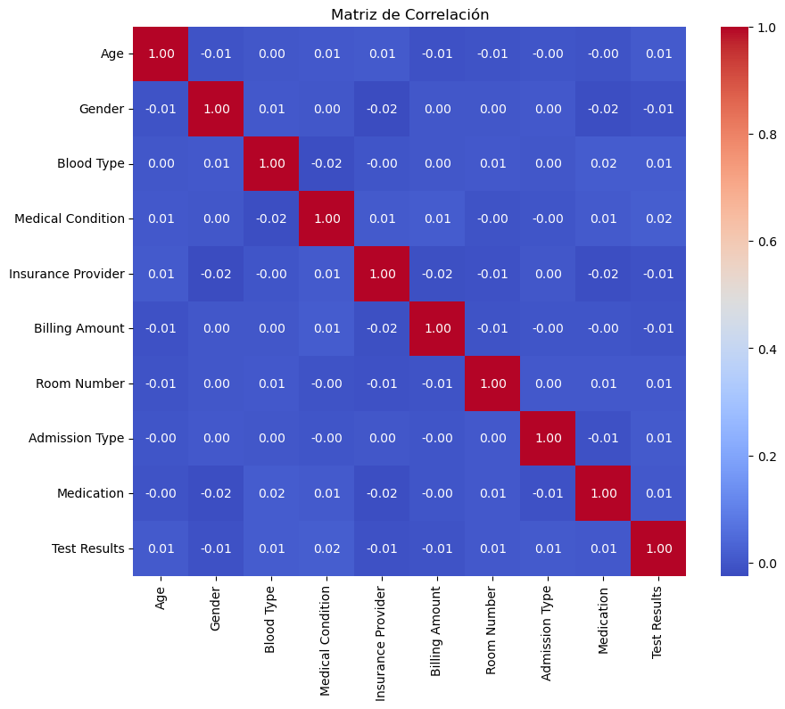

```python
dfcorrel = df.copy()

# Calcular la matriz de correlación
correlation_matrix = dfcorrel.corr()

# Visualizar la matriz de correlación como un mapa de calor
plt.figure(figsize=(10, 8))
sns.heatmap(correlation_matrix, annot=True, cmap='coolwarm', fmt='.2f')
plt.title('Matriz de Correlación')
plt.show()
```

### Implementación

```python
from sklearn.model_selection import train_test_split
from sklearn.preprocessing import StandardScaler
from sklearn.neighbors import KNeighborsClassifier
```

#### Evaluación de Modelos

```python
from sklearn.metrics import accuracy_score, precision_score, recall_score, f1_score, confusion_matrix, classification_report
```

#### KNN

```python
X = df.drop('Test Results', axis=1)
y = df['Test Results']
X_train, X_test, y_train, y_test = train_test_split(X, y, test_size=0.2, random_state=42)
```

```python
scaler = StandardScaler()
scaler.fit(X_train)
```

```
StandardScaler()
```

```python
X_train = scaler.transform(X_train)
X_test = scaler.transform(X_test)
```

```python
knn_model = KNeighborsClassifier(n_neighbors=5)
knn_model.fit(X_train, y_train)
```

```
KNeighborsClassifier()
```

```python
y_pred = knn_model.predict(X_test)
```

```python
precision = precision_score(y_test, y_pred, average='macro')
print(f"Precisión: {precision:.2f}")
```

```
Precisión: 0.37
```

```python
recall = recall_score(y_test, y_pred, average='macro')
print(f"Sensibilidad (Recall): {recall:.2f}")
```

```
Sensibilidad (Recall): 0.36
```

```python
f1 = f1_score(y_test, y_pred, average='macro')
print(f"F1 Score: {f1:.2f}")
```

```
F1 Score: 0.36
```

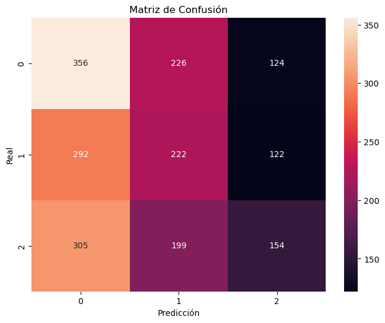

```python
# Calcular la matriz de confusión
conf_matrix = confusion_matrix(y_test, y_pred)

# Visualizar la matriz de confusión con seaborn
plt.figure(figsize=(8, 6))
sns.heatmap(conf_matrix, annot=True, fmt='d')
plt.title('Matriz de Confusión')
plt.xlabel('Predicción')
plt.ylabel('Real')
plt.show()
```

#### Árboles de Desición

```python
from sklearn.tree import DecisionTreeClassifier
```

```python
clf = DecisionTreeClassifier(random_state=42)
clf.fit(X_train, y_train)
```

```
DecisionTreeClassifier(random_state=42)
```

```python
y_pred = clf.predict(X_test)
```

```python
precision = precision_score(y_test, y_pred, average='macro')
print(f"Precisión: {precision:.2f}")
```

```
Precisión: 0.32
```

```python
recall = recall_score(y_test, y_pred, average='macro')
print(f"Sensibilidad (Recall): {recall:.2f}")
```

```
Sensibilidad (Recall): 0.32
```

```python
f1 = f1_score(y_test, y_pred, average='macro')
print(f"F1 Score: {f1:.2f}")
```

```
F1 Score: 0.32
```

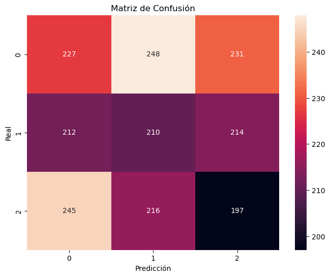

```python
# Calcular la matriz de confusión
conf_matrix = confusion_matrix(y_test, y_pred)

# Visualizar la matriz de confusión con seaborn
plt.figure(figsize=(8, 6))
sns.heatmap(conf_matrix, annot=True, fmt='d')
plt.title('Matriz de Confusión')
plt.xlabel('Predicción')
plt.ylabel('Real')
plt.show()
```

### Discusión

Discusión General:

Desempeño Bajo: Ambos modelos muestran un desempeño bajo en términos de precisión, sensibilidad y F1 Score. Esto puede deberse a varios factores, como la elección de parámetros, la calidad de los datos o la naturaleza intrínseca del problema.

Posibles Mejoras:

- Ajuste de Parámetros: Experimenta con diferentes valores para los parámetros del modelo, como el número de vecinos en KNN o la profundidad máxima en Árboles de Decisión.
- Selección de Características: Considera si todas las características son relevantes o si se pueden mejorar mediante ingeniería de características.
- Validación Cruzada: Utiliza técnicas de validación cruzada para obtener estimaciones más confiables del rendimiento del modelo.
- Otras Técnicas de Modelado: Explora otras técnicas de clasificación, como Random Forests, Support Vector Machines, o modelos de ensamblaje.
- Análisis de Errores: Examina las instancias que fueron clasificadas incorrectamente para comprender mejor las debilidades del modelo y si hay patrones específicos que no está capturando.

En resumen, el bajo rendimiento puede deberse a diversos factores, y es necesario un análisis más detallado y ajustes en la configuración de los modelos para mejorar la eficacia de la clasificación. La exploración de otras técnicas de modelado y la comprensión profunda del problema también pueden ser beneficiosas.

### Referencias

[1] scikit-learn developers. “1.4. support vector machines”. scikit-learn. Accedido el 14 de noviembre de 2023. [En línea]. Disponible: https://scikit-learn.org/stable/modules/svm.html

[2] scikit-learn developers. “1.5. stochastic gradient descent”. scikit-learn. Accedido el 14 de noviembre de 2023. [En línea]. Disponible: https://scikit-learn.org/stable/modules/sgd.html

[3] scikit-learn developers. “1.6. nearest neighbors”. scikit-learn. Accedido el 14 de noviembre de 2023. [En línea]. Disponible: https://scikit-learn.org/stable/modules/neighbors.html

[4] scikit-learn developers. “1.9. naive bayes”. scikit-learn. Accedido el 14 de noviembre de 2023. [En línea]. Disponible: https://scikit-learn.org/stable/modules/naive_bayes.html

[5] scikit-learn developers. “1.10. decision trees”. scikit-learn. Accedido el 14 de noviembre de 2023. [En línea]. Disponible: https://scikit-learn.org/stable/modules/tree.html

[6] scikit-learn developers. “1.17. Neural network models (supervised)”. scikit-learn. Accedido el 14 de noviembre de 2023. [En línea]. Disponible: https://scikit-learn.org/stable/modules/neural_networks_supervised.html